# Measuring NBA Player Performance using Advanced NBA Statistics

Project Report for STAT 303-1 Fall 2025

Author

George Sun

Published

December 9, 2025

Abstract

*In this report, we analyze NBA player performance using advanced analytics. We examine which players have the most impact to their team’s ability to win as well as which player has maintained the highest level of performance over the course of a 20+ year career. The analysis reveals that current superstars like Nikola Jokic and Giannis Antetokounmpo contribute to their team the most in terms of wins, measured by Win Shares (WS). We considered variables such as Box Plus/Minus (BPM) and Points Per Game (PPG). Over the course of a 20+ year career, we saw that Lebron James has maintained an elite level of performance. Based on these findings, we recommend that stakeholders prioritize stats like BPM, WS, and VORP when evaluating a player’s performance and ability to mesh with a team*.

## 1) Inspiration

My interest in and passion for basketball motivated me to choose to analyze NBA data for this project. I have been playing basketball all my life and I’ve been a fan for equally as long. I have always been interested in examining different player’s stats after games. For example, if a player had 25 points and 5 assists, it might seem like they had a good game; but what interested me more was looking at his productivity–maybe he had a low FG%, a high USG%, and a low AST-TOV ratio. Especially now with my knowledge in data science, I think I will be able to analyze this NBA data effectively. Data is extremely important in sports and a lot of casual fans are oftentimes influenced by their personal opinions when making statements. I think it will be worth exploring the NBA data to make data-driven conclusions on some questions I have.

## 2) Problem Statements

1. **Among players who played in all of the past five NBA seasons (in the dataset, so from 2019-20 to 2023-24 season), who was the most impactful to their team’s success?**
2. **Who has maintained the highest level of basketball performance over the course of a 20+ year career?**

## 3) Data

**NBA Player Data (1996-2024) Dataset:** https://www.kaggle.com/datasets/damirdizdarevic/nba-dataset-eda-and-ml-compatible/code

**Description:** This dataset is from Kaggle, the world’s largest data science community. This is a dataset containing NBA Player Data from 1996 to 2024. It includes information such as height in cm, weight in kg, game stats, biographical information, and more.

**Data Description:**

The dataset has 13391 observations, and 36 variables. Each observation represents a different basketball player’s season in the dataset. Each variable represents different categories such as pts (Points per Game), draft_year, BPM (Box Plus Minus for that player’s season)

28 of the variables are numeric, and 7 are categorical. The variable “normalized_name” is non-numeric and is not a categorical variable since each name is unique.

Altogether, seven variables are used for all the analysis in the report.

## 4) Stakeholders

The stakeholders of this analysis include NBA and basketball enthusiasts. These are the individuals would be interested seeing the results and analysis. The stakeholders could also be basketball insiders, writers, and those working in the NBA. This analysis could benefit parties to make more qualified and data-driven claims. In addition, such analysis could be used when determining post-season awards, even.

Moreover, General Managers of teams could benefit by using my data when deciding who to draft or acquire. Certain stats might correlate more to team success than others, as will be investigated in this report.

## 5) Data Cleaning

### a) Cleaning - Question 1

Of the variables that I focus on in my analysis (‘pts’, ‘WS’, ‘BPM’), none have missing values. The variables of interest did not need any imputation because the values exist, are legitamate, and make sense in the scope of the dataset.

Of the four numeric variables I analyze, the ‘MP.x’ variable has 0 outliers, the ‘pts’ variable has 0 outliers, the ‘WS’ variable has 10 outliers and the ‘BPM’ variable has 8 outliers. I decided to keep the outliers because they help provide insights on the spectrum of performances from players. Outliers in this context help show contrast between high-impact players, average players and low-impact players in terms of highlighting superstar performances, rather than the outliers being errors. Removing them would obscure the players who impact the game at a high level, when looking at ‘pts’, ‘WS’ and ‘BPM’.

The only categorical variable I used in the analysis was ‘normalized_name’, which is the variable containing player names. I cleaned the dataframe so that each observation was a unique player with their season statistical averages. As a result, since every value in ‘normalized_name’ is unique, it does not form meaningful categories; thus, there are effectively zero categories in the categorical variable, ‘normalized_name’.

Each variable was important. They all contain corresponding statistics for each player.

A few additional things I did in terms of cleaning is that since the question called for the most impactful player to winning for their team among players who played in all of the past five NBA seasons in the dataset (so from the 2019-20 season up to the 2023-24 season), I filtered to only include players who appeared in those five distinct NBA seasons. On top of that, there are a plethora of variables in the dataset that do not help to show winnning and impact as much as others or are completely unrelated to the scope of the question; stats like rebounds and height could be omitted. I only incorporated the following variables in my analysis for this question: ‘normalized_name’, ‘MP.x’, ‘pts’, ‘WS’, ‘BPM’.

### b) Cleaning - Question 2

Among the variables used in the analysis, there are no missing values. As a result, there is no need to impute. Furthermore, upon calculations, there are no outliers present in the numeric variables (‘pts’, and ‘VORP’) used for this analysis. The categorical variables used for this analysis is ‘season’ and ‘normalized_name’. There are 28 total categories for the ‘season’ variable, each representing a specific NBA season. There are no incorrect values.

For this analysis, I have also filtered the dataset so that only players who have played 20 or more NBA seasons are kept.

I also dropped all variables except for ‘normalized_name’, ‘season’, ‘pts’, and ‘VORP’ for this analysis.

### a) Analysis 1

**Methodology**

To prepare the data for visualization, I filtered the dataset so that only players who played an average of 15 or more minutes would appear. When I was conducting my analysis prior to this fact, I noticed that some players’ BPM were extremely high when their minutes were very low. The statistic in itself measures a player’s total contribution to their team per 100 possessions, so when a player plays a very short amount of time, their BPM could be absurdly high.

For the first plot, a boxplot, I grouped the BPM into three ranges of values: Low BPM (-5.437, 0.347], Medium BPM (0.347, 6.113], High BPM (6.113, 11.88]. For the groupings, the .cut function was used to ensure the BPM groupings were of equal ranges. This way, we can see how players in each of these groups affect WS.

#### 1) Boxplot: Win Share Distribution by BPM

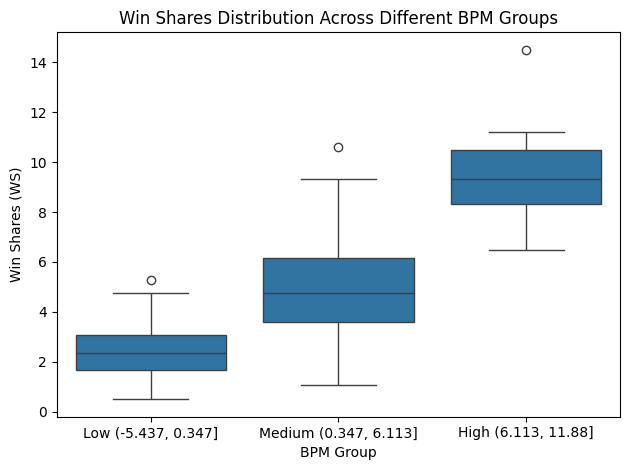

|  | BPM Group | Q1 | Q3 | IQR | Lower Fence | Upper Fence | Number of Outliers |
| --- | --- | --- | --- | --- | --- | --- | --- |
| 0 | Medium (0.347, 6.113] | 3.58 | 6.15 | 2.56 | -0.26 | 10.00 | 1 |
| 1 | Low (-5.437, 0.347] | 1.66 | 3.08 | 1.42 | -0.46 | 5.20 | 1 |
| 2 | High (6.113, 11.88] | 8.33 | 10.49 | 2.16 | 5.09 | 13.73 | 1 |

**Results for Graph 1**

Win shares is an advanced statistic that estimates a player’s contribution to their team’s wins. The statistic looks at individual offensive and defensive production. Essentially, if a player has a Win Share of seven for some season, that would mean the player is estimated to have contributed the equivalent of about seven team wins over that full season.

|  | normalized_name | MP.x | pts | WS | BPM | BPM_grouping |
| --- | --- | --- | --- | --- | --- | --- |
| 191 | Nikola Jokic | 33.68 | 24.86 | 14.5 | 11.88 | High (6.113, 11.88] |

#### 2) Regression Plot: Points per Game vs Win Shares

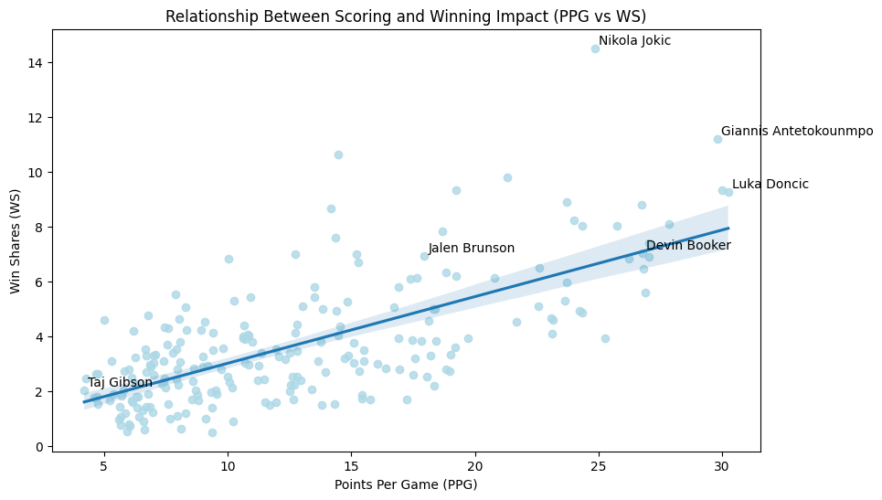

|  | normalized_name | pts | WS |
| --- | --- | --- | --- |
| 162 | Luka Doncic | 30.24 | 9.26 |
| 122 | Joel Embiid | 29.98 | 9.32 |
| 90 | Giannis Antetokounmpo | 29.80 | 11.20 |
| 44 | Damian Lillard | 27.86 | 8.08 |
| 234 | Trae Young | 27.04 | 6.88 |

|  | normalized_name | pts | WS |
| --- | --- | --- | --- |
| 127 | Jordan McLaughlin | 4.72 | 1.78 |
| 196 | P.J. Tucker | 4.68 | 2.64 |
| 57 | Dean Wade | 4.62 | 1.76 |
| 124 | John Konchar | 4.26 | 2.46 |
| 223 | Taj Gibson | 4.20 | 2.02 |

**Results for Graph 2**

The regression line, drawn in blue, shows the average relationship between PPG and WS. It shows whether or not players who score more tend to contribute to more winning basketball for their team, and by how much.

The line has a positive slope, which means that higher scores do tend to generate more wins. This relationship is somewhat strong; we see that the confidence interval, visualized by the shaded blue band, starts narrow then widens a bit as PPG and WS increase in value. The line is helpful in showing outliers that pop out. We see that players like Nikola Jokic and Giannis Antetokounmpo are situated on the top right of the graph, meaning they score a lot and the points they score contribute to team wins. Other players like Devin Booker, hover closer to the line of best fit. If we look further to the left of the graph, we see more rotational or ‘bench’ players. Taj Gibson, from the 2019-20 season to the 2023-24 season, averaged 4.2 PPG and 2.02 WS. It might seem like his impact was negligible, but real-life context matters. Gibson is a veteran, having played 10 seasons up to the 2019-20 season. Teams tend to keep players like Gibson around to help mentor their rookies.

Below the graph, I also included a snapshot of the top five and bottom five players in terms of PPG and their respective WS.

Overall, it could be concluded that, among players who played in all of the past five NBA seasons, Nikola Jokic is the most impactful to his team’s success in terms of wins. Jokic might not have the highest PPG among players in the dataset, but his other skillsets, such as his passing and playmaking, make him a vital factor in his team’s wins.

### b) Analysis 2

**Methodology**

To prepare the data for visualization, I filtered the dataset so that only players who have played 20 or more seasons are included. This is outlined in the data cleaning section already.

Furthermore, for the first graph, we wrangled the data and merged our ‘players_20_or_more’ with our ‘nba_data’. Essentially, we took the full NBA dataset and kept only the rows where the player name appears in the list of players with 20+ seasons. Other things includes only keeping the variables, ‘normalized_name’, ‘season’, ‘pts’, and ‘VORP’.

For the second graph, we used .pivot_table() to take the long dataframe, where we had one player per row per season, and reshaped it into a matrix where each row became a unique player, each column corresponded to a different season, and each value was a respective player’s VORP in that season. This is necessary to create the heatmap.

#### 1) Lineplot: PPG Over Career for Players With 20+ NBA Seasons

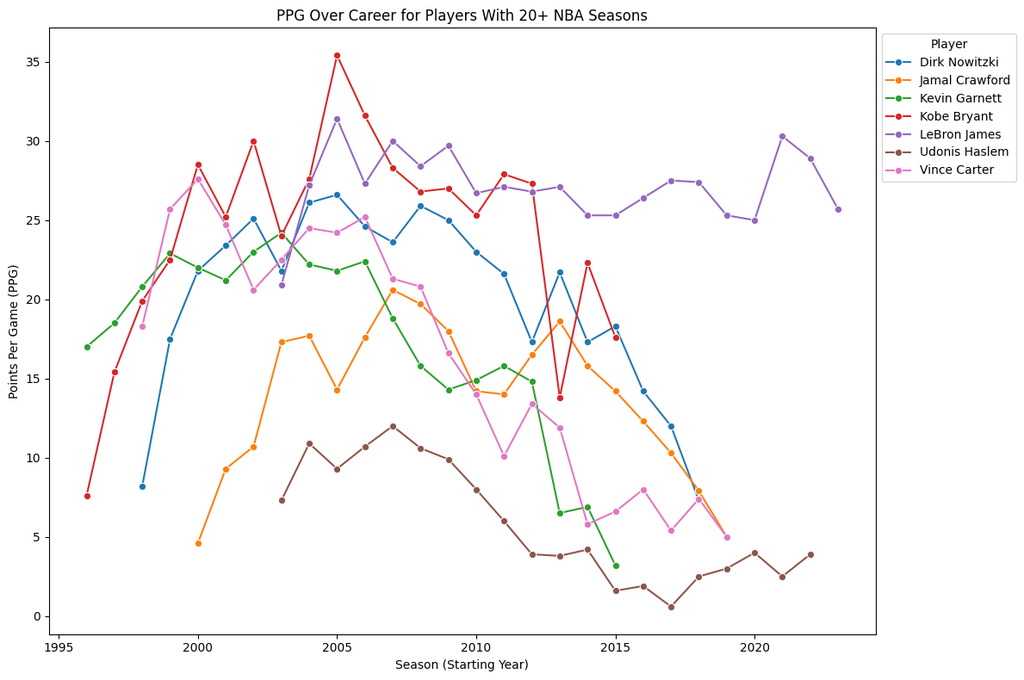

**Results for Graph 1**

This lineplot shows how each player’s scoring (PPG) changes acorss every season of their career. This is a plot for only player’s who have played 20 or more NBA seasons. Each line represents a unique player’s PPG over time, starting from their rookie year to the year they retired (or to the end of the original dataset, since Lebron has yet to retire). The x-axis shows the starting year of each season and the y-axis shows how many points the player averaged that season.

This graph shows each player’s scoring peak. Kobe peaks around the 2005-06 season, for instance. But the plot also visualizes longevity in a way that is very clear. We see that some players like Dirk and Kobe can produce at high levels past their 10th season, but they, along with most other players, experience a steep decline close to their retirement years. However, Lebron’s slope barely declines going into his 20th season, an impressive feat that only he has accomplished. James clearly is the only player who has maintained an elite level of basketball performance and scoring production among those who have played 20+ NBA seasons.

#### 2) Heatmap: Season-by-Season VORP for NBA Players with 20+ Seasons

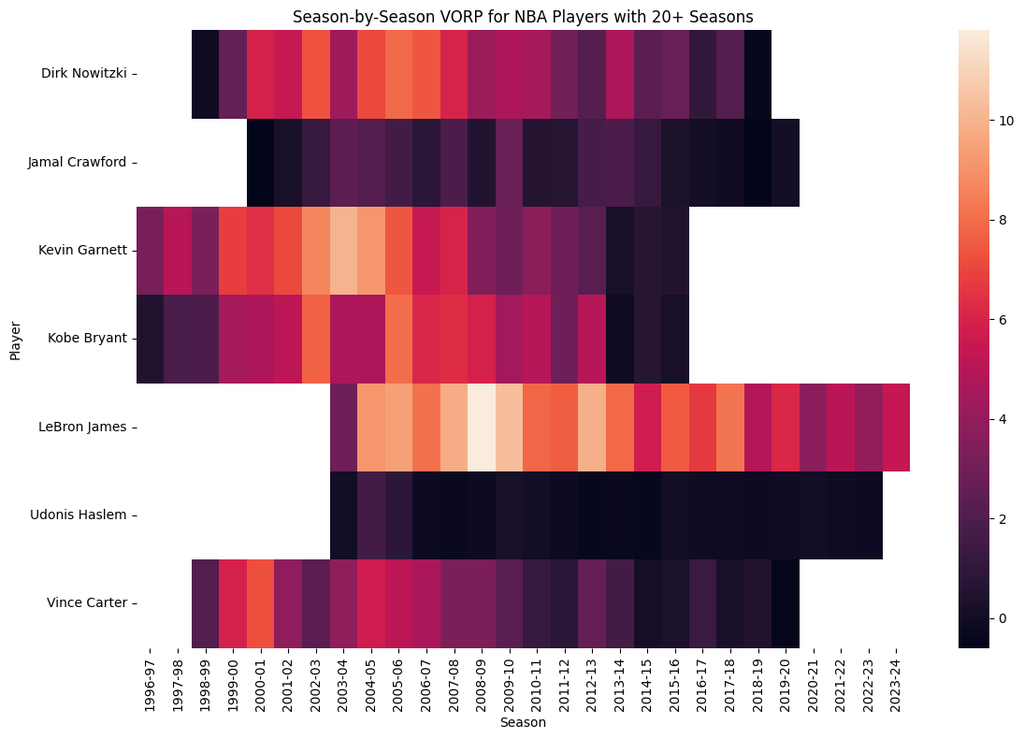

| normalized_name | Dirk Nowitzki | Jamal Crawford | Kevin Garnett | Kobe Bryant | LeBron James | Udonis Haslem | Vince Carter |
| --- | --- | --- | --- | --- | --- | --- | --- |
| Dirk Nowitzki | 1.000000 | 0.415963 | 0.585357 | 0.662474 | 0.412818 | 0.546518 | 0.602536 |
| Jamal Crawford | 0.415963 | 1.000000 | 0.129549 | 0.050358 | 0.230673 | 0.323104 | 0.233833 |
| Kevin Garnett | 0.585357 | 0.129549 | 1.000000 | 0.693848 | -0.171634 | 0.606606 | 0.717186 |
| Kobe Bryant | 0.662474 | 0.050358 | 0.693848 | 1.000000 | 0.396758 | 0.321471 | 0.565076 |
| LeBron James | 0.412818 | 0.230673 | -0.171634 | 0.396758 | 1.000000 | 0.205112 | 0.364811 |
| Udonis Haslem | 0.546518 | 0.323104 | 0.606606 | 0.321471 | 0.205112 | 1.000000 | 0.602028 |
| Vince Carter | 0.602536 | 0.233833 | 0.717186 | 0.565076 | 0.364811 | 0.602028 | 1.000000 |

**Results for Graph 2**

This is a heatmap that shows the VORP corresponding to each player for a specific season. Looking at the scale on the right, the VORP can be negative and goes up to a VORP of 11.8. VORP is also known as Value over Replacement Player which converts the BPM into an estimate of each player’s overall contribution to the team, measured vs a theoretical ‘replacement player’. A player with a high VORP offers a more positive impact compared to a G-League call-up player or a bench player. A higher VORP means the player drives winning more and is performing at a higher level.

With the legend on the right, we can see that players with lighter all-round colors are more elite performers. On top of that, if their entire bar is consistently light-color, that would mean the player is consistently playing at a high level—and we see exactly that with LeBron, therefore cementing our finding that Lebron James has maintained the most elite level of basketball performance across his 20+ seasons. Visually, most players’ boxes turn darker as their seasons go on, eventually turning completely black, but James is far from that.

## 7) Recommendations to Stakeholders

### a) Recommendations 1

The analysis shows a strong relationship between BPM and WS. Players with high BPM also produce the most WS, meaning they directly help their team win. Furthermore, the analysis shows that higher PPG does not automatically mean higher WS. Stakeholders such as General Managers could look at this data and consider investing in players with high BPM stats instead of solely looking at players who generate a lot of points.

A clear limitation is that the analysis is only performed on players who played all five seasons between 2019-2024. This excludes information from rising stars and excludes players who may have missed a season between 2019-2024 due to injury. Also, if we looked at the data prior to 2019, our results could be different.

To overcome this limitation, we should expand our dataset to include more players and possibly split players by position to see if there is a trend there.

### b) Recommendations 2

For avid basketball fans, the analysis highlights the elite level of basketball play Lebron James has sustained over the course of his 20+ season career. For General Managers, the VORP heatmap could help in terms of recognizing early signs of regression and decline. This could help teams avoid overpaying contracts that go into a player’s forecasted decline years.

The limitations of this analysis is that only a handful of players have lasted 20+ seasons. If we expanded our anlaysis to players with 15+ seasons, more trends would likely appear. To combat this limitation, further analysis is necessary, such as organizing the data and stats for all players with 15+ seasons, for example.

## 8) Conclusion

When different advanced statistical metrics are brought together and compared, a clearer picture of what drives winning in the NBA begins to emerge. Each question focused on a different part of the game: scoring, on versus off court statistics, on-court impact, longevity.

The combined results show that the most impactful players contribute to the game in multiple ways. Their Box Plus/Minus must first be at an elite level to contribute to winning games. But above all, the results of this analysis still do point to the fact that scoring is one of the most important skills and metrics in the game. Players with high PPG averages tend to have higher a Box Plus/Minus number, higher Win Shares, and a better VORP.